# CV2_project1

1. Import and Understand the data

```python
import os
import cv2
import keras
import pandas             as pd
import matplotlib.pyplot  as plt
import matplotlib.patches as patches

import numpy              as np
import tensorflow         as tf
import pickle
import os
from glob import glob



from zipfile import ZipFile
%tensorflow_version 2.x
import tensorflow
tensorflow.__version__
```

```
Colab only includes TensorFlow 2.x; %tensorflow_version has no effect.
```

```
'2.9.2'
```

```python
from google.colab import drive
drive.mount('/content/drive')
```

A. Import and read ‘images.npy’

```python
print(os.listdir("../content"))
```

```
['.config', 'drive', 'sample_data']
```

```python
data = np.load('/content/drive/MyDrive/data/CV2/images.npy', allow_pickle = True)
data.shape
```

```
(409, 2)
```

```python
type(data)
```

```
numpy.ndarray
```

```python
images = data[:,0]
mask = data[:,1]
print("Image Shape",images.shape)
print("Mask Shape",mask.shape)
```

```
Image Shape (409,)
Mask Shape (409,)
```

```python
type(mask)
```

```
numpy.ndarray
```

[figure not shown]

```python
plt.imshow(images[275])
```

```python
display(mask[275] )
```

```
[{'label': ['Face'],
  'notes': '',
  'points': [{'x': 0.40082644628099173, 'y': 0.13488372093023257},
   {'x': 0.5113636363636364, 'y': 0.32558139534883723}],
  'imageWidth': 1024,
  'imageHeight': 683}]
```

[figure not shown]

```python
fig, ax = plt.subplots(nrows=1, ncols=1,figsize=(10, 5))
ax.imshow(data[275][0])
for lbl in data[275][1]:
    rect = patches.Rectangle((lbl['points'][0]['x']*lbl['imageWidth'], lbl['points'][0]['y']*lbl['imageHeight']), lbl['points'][1]['x']*lbl['imageWidth'] - lbl['points'][0]['x']*lbl['imageWidth'], lbl['points'][1]['y']*lbl['imageHeight']- lbl['points'][0]['y']*lbl['imageHeight'], linewidth=2, edgecolor='r', facecolor='none')
    ax.add_patch(rect)
```

B. Split the data into Features(X) & labels(Y). Unify shape of all the images.

Here feature is the image The label is the mask Images will be stored in "X" array Masks will be stored in "masks" array

Unify shape of images to 224

```python
IMAGE_WIDTH = 224
IMAGE_HEIGHT = 224
ALPHA = 1
```

```python
import cv2
from tensorflow.keras.applications.mobilenet import preprocess_input

masks = np.zeros((int(data.shape[0]), IMAGE_HEIGHT, IMAGE_WIDTH))
X = np.zeros((int(data.shape[0]), IMAGE_HEIGHT, IMAGE_WIDTH, 3))
for index in range(data.shape[0]):
    img = data[index][0]
    img = cv2.resize(img, dsize=(IMAGE_HEIGHT, IMAGE_WIDTH), interpolation=cv2.INTER_CUBIC)
    try:
      img = img[:, :, :3]
    except:
      continue
    X[index] = preprocess_input(np.array(img, dtype=np.float32))
    for i in data[index][1]:
        x1 = int(i["points"][0]['x'] * IMAGE_WIDTH)
        x2 = int(i["points"][1]['x'] * IMAGE_WIDTH)
        y1 = int(i["points"][0]['y'] * IMAGE_HEIGHT)
        y2 = int(i["points"][1]['y'] * IMAGE_HEIGHT)
        masks[index][y1:y2, x1:x2] = 1
```

```python
print("X Shape",X.shape)
print("mask Shape",masks.shape)
```

```
X Shape (409, 224, 224, 3)
mask Shape (409, 224, 224)
```

*C*. Split the data into train and test[400:9].

```python
from sklearn.model_selection import train_test_split
X_train, X_test, y_train, y_test = train_test_split(X, masks,train_size=400 ,test_size=9)
```

```python
print("X Train Shape",X_train.shape)
print("X Test Shape",X_test.shape)
print("Y Train Shape",y_train.shape)
print("Y Test Shape",y_test.shape)
```

```
X Train Shape (400, 224, 224, 3)
X Test Shape (9, 224, 224, 3)
Y Train Shape (400, 224, 224)
Y Test Shape (9, 224, 224)
```

Orginal Image

```
WARNING:matplotlib.image:Clipping input data to the valid range for imshow with RGB data ([0..1] for floats or [0..255] for integers).
```

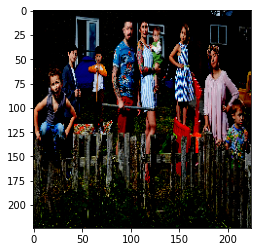

```python
from matplotlib import pyplot
n = 75
pyplot.imshow(X_train[n])
```

Masked Image

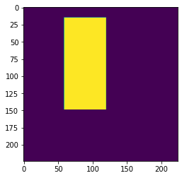

```python
pyplot.imshow(masks[n])
```

1. Model building

Add MobileNet as model with below parameter values input_shape: IMAGE_HEIGHT, IMAGE_WIDTH, 3 include_top: False alpha: 1.0 weights: "imagenet" Add UNET architecture layers This is the trickiest part of the project, you need to research and implement it correctly

```python
model = MobileNet(input_shape=(IMAGE_HEIGHT, IMAGE_WIDTH, 3), include_top=False, alpha=ALPHA, weights="imagenet")
model.summary()
```

```
Model: "mobilenet_1.00_224"
_________________________________________________________________
 Layer (type)                Output Shape              Param #
=================================================================
 input_5 (InputLayer)        [(None, 224, 224, 3)]     0

 conv1 (Conv2D)              (None, 112, 112, 32)      864

 conv1_bn (BatchNormalizatio  (None, 112, 112, 32)     128
 n)

 conv1_relu (ReLU)           (None, 112, 112, 32)      0

 conv_dw_1 (DepthwiseConv2D)  (None, 112, 112, 32)     288

 conv_dw_1_bn (BatchNormaliz  (None, 112, 112, 32)     128
 ation)

 conv_dw_1_relu (ReLU)       (None, 112, 112, 32)      0

 conv_pw_1 (Conv2D)          (None, 112, 112, 64)      2048

 conv_pw_1_bn (BatchNormaliz  (None, 112, 112, 64)     256
 ation)

 conv_pw_1_relu (ReLU)       (None, 112, 112, 64)      0

 conv_pad_2 (ZeroPadding2D)  (None, 113, 113, 64)      0

 conv_dw_2 (DepthwiseConv2D)  (None, 56, 56, 64)       576

 conv_dw_2_bn (BatchNormaliz  (None, 56, 56, 64)       256
 ation)

 conv_dw_2_relu (ReLU)       (None, 56, 56, 64)        0

 conv_pw_2 (Conv2D)          (None, 56, 56, 128)       8192

 conv_pw_2_bn (BatchNormaliz  (None, 56, 56, 128)      512
 ation)
```

[output cut: 157 more lines]

```

 conv_dw_13_relu (ReLU)      (None, 7, 7, 1024)        0

 conv_pw_13 (Conv2D)         (None, 7, 7, 1024)        1048576

 conv_pw_13_bn (BatchNormali  (None, 7, 7, 1024)       4096
 zation)

 conv_pw_13_relu (ReLU)      (None, 7, 7, 1024)        0

=================================================================
Total params: 3,228,864
Trainable params: 3,206,976
Non-trainable params: 21,888
_________________________________________________________________
```

```python
from tensorflow.keras.applications.mobilenet import MobileNet
from tensorflow.keras.layers import Concatenate, UpSampling2D, Conv2D, Reshape
from tensorflow.keras.models import Model


def create_model(trainable=True):
    model = MobileNet(input_shape=(IMAGE_HEIGHT, IMAGE_WIDTH, 3), include_top=False, alpha=ALPHA, weights="imagenet")

    for layer in model.layers:
        layer.trainable = trainable

    block1 = model.get_layer("conv_pw_5_relu").output
    block2 = model.get_layer("conv_pw_11_relu").output
    block3 = model.get_layer("conv_pw_13_relu").output

    x = Concatenate()([UpSampling2D()(block3), block2])
    x = Concatenate()([UpSampling2D()(x), block1])

    x = Conv2D(1, kernel_size=1, activation="sigmoid")(x)
    x = Reshape((28, 28))(x)

    return Model(inputs=model.input, outputs=x)
```

```python
# Give trainable=False as argument, if you want to freeze lower layers for fast training (but low accuracy)
ALPHA=1

model = create_model()

# Print summary
model.summary()
```

```
Model: "model_5"
__________________________________________________________________________________________________
 Layer (type)                   Output Shape         Param #     Connected to
==================================================================================================
 input_8 (InputLayer)           [(None, 224, 224, 3  0           []
                                )]

 conv1 (Conv2D)                 (None, 112, 112, 32  864         ['input_8[0][0]']
                                )

 conv1_bn (BatchNormalization)  (None, 112, 112, 32  128         ['conv1[0][0]']
                                )

 conv1_relu (ReLU)              (None, 112, 112, 32  0           ['conv1_bn[0][0]']
                                )

 conv_dw_1 (DepthwiseConv2D)    (None, 112, 112, 32  288         ['conv1_relu[0][0]']
                                )

 conv_dw_1_bn (BatchNormalizati  (None, 112, 112, 32  128        ['conv_dw_1[0][0]']
 on)                            )

 conv_dw_1_relu (ReLU)          (None, 112, 112, 32  0           ['conv_dw_1_bn[0][0]']
                                )

 conv_pw_1 (Conv2D)             (None, 112, 112, 64  2048        ['conv_dw_1_relu[0][0]']
                                )

 conv_pw_1_bn (BatchNormalizati  (None, 112, 112, 64  256        ['conv_pw_1[0][0]']
 on)                            )

 conv_pw_1_relu (ReLU)          (None, 112, 112, 64  0           ['conv_pw_1_bn[0][0]']
                                )

 conv_pad_2 (ZeroPadding2D)     (None, 113, 113, 64  0           ['conv_pw_1_relu[0][0]']
                                )

 conv_dw_2 (DepthwiseConv2D)    (None, 56, 56, 64)   576         ['conv_pad_2[0][0]']

 conv_dw_2_bn (BatchNormalizati  (None, 56, 56, 64)  256         ['conv_dw_2[0][0]']
```

[output cut: 177 more lines]

```
 up_sampling2d_23 (UpSampling2D  (None, 28, 28, 1536  0          ['concatenate_22[0][0]']
 )                              )

 concatenate_23 (Concatenate)   (None, 28, 28, 1792  0           ['up_sampling2d_23[0][0]',
                                )                                 'conv_pw_5_relu[0][0]']

 conv2d_5 (Conv2D)              (None, 28, 28, 1)    1793        ['concatenate_23[0][0]']

 reshape_5 (Reshape)            (None, 28, 28)       0           ['conv2d_5[0][0]']

==================================================================================================
Total params: 3,230,657
Trainable params: 3,208,769
Non-trainable params: 21,888
__________________________________________________________________________________________________
```

B. Design your own Dice Coefficient and Loss function.

```python
def dice_coefficient(y_true, y_pred):
    numerator = 2 * tf.reduce_sum(y_true * y_pred)
    denominator = tf.reduce_sum(y_true + y_pred)

    return numerator / (denominator + tf.keras.backend.epsilon())
```

```python
from tensorflow.keras.losses import binary_crossentropy
from tensorflow.keras.backend import log, epsilon
def loss(y_true, y_pred):
    return binary_crossentropy(y_true, y_pred) - log(dice_coefficient(y_true, y_pred) + epsilon())
```

```python
from tensorflow.keras.optimizers import Adam
import tensorflow as tf
optimizer = Adam(lr=1e-4, beta_1=0.9, beta_2=0.999, epsilon=None, decay=0.0, amsgrad=False)
model.compile(loss=loss, optimizer=optimizer, metrics=[dice_coefficient])
```

```python
model = create_model(False)
model.summary()
optimizer = tf.keras.optimizers.Adam(lr=1e-4, beta_1=0.9, beta_2=0.999, epsilon=None, decay=0.0, amsgrad=False)
model.compile(loss=loss, optimizer = optimizer, metrics=[dice_coefficient])
```

```
Model: "model_6"
__________________________________________________________________________________________________
 Layer (type)                   Output Shape         Param #     Connected to
==================================================================================================
 input_9 (InputLayer)           [(None, 224, 224, 3  0           []
                                )]

 conv1 (Conv2D)                 (None, 112, 112, 32  864         ['input_9[0][0]']
                                )

 conv1_bn (BatchNormalization)  (None, 112, 112, 32  128         ['conv1[0][0]']
                                )

 conv1_relu (ReLU)              (None, 112, 112, 32  0           ['conv1_bn[0][0]']
                                )

 conv_dw_1 (DepthwiseConv2D)    (None, 112, 112, 32  288         ['conv1_relu[0][0]']
                                )

 conv_dw_1_bn (BatchNormalizati  (None, 112, 112, 32  128        ['conv_dw_1[0][0]']
 on)                            )

 conv_dw_1_relu (ReLU)          (None, 112, 112, 32  0           ['conv_dw_1_bn[0][0]']
                                )

 conv_pw_1 (Conv2D)             (None, 112, 112, 64  2048        ['conv_dw_1_relu[0][0]']
                                )

 conv_pw_1_bn (BatchNormalizati  (None, 112, 112, 64  256        ['conv_pw_1[0][0]']
 on)                            )

 conv_pw_1_relu (ReLU)          (None, 112, 112, 64  0           ['conv_pw_1_bn[0][0]']
                                )

 conv_pad_2 (ZeroPadding2D)     (None, 113, 113, 64  0           ['conv_pw_1_relu[0][0]']
                                )

 conv_dw_2 (DepthwiseConv2D)    (None, 56, 56, 64)   576         ['conv_pad_2[0][0]']

 conv_dw_2_bn (BatchNormalizati  (None, 56, 56, 64)  256         ['conv_dw_2[0][0]']
```

[output cut: 177 more lines]

```
 up_sampling2d_25 (UpSampling2D  (None, 28, 28, 1536  0          ['concatenate_24[0][0]']
 )                              )

 concatenate_25 (Concatenate)   (None, 28, 28, 1792  0           ['up_sampling2d_25[0][0]',
                                )                                 'conv_pw_5_relu[0][0]']

 conv2d_6 (Conv2D)              (None, 28, 28, 1)    1793        ['concatenate_25[0][0]']

 reshape_6 (Reshape)            (None, 28, 28)       0           ['conv2d_6[0][0]']

==================================================================================================
Total params: 3,230,657
Trainable params: 1,793
Non-trainable params: 3,228,864
__________________________________________________________________________________________________
```

C. Train and tune the model as required.

```python
from tensorflow.keras.callbacks import ModelCheckpoint, EarlyStopping, ReduceLROnPlateau
checkpoint = ModelCheckpoint("model-{loss:.2f}.h5", monitor="loss", verbose=1, save_best_only=True,
                             save_weights_only=True, mode="min", period=1)
stop = EarlyStopping(monitor="loss", patience=5, mode="min")
reduce_lr = ReduceLROnPlateau(monitor="loss", factor=0.2, patience=5, min_lr=1e-6, verbose=1, mode="min")
```

```
WARNING:tensorflow:`period` argument is deprecated. Please use `save_freq` to specify the frequency in number of batches seen.
```

```python
masks_resize= np.zeros((int(y_train.shape[0]), 28,28))
for index in range(y_train.shape[0]):
  masks_resize[index]= cv2.resize(y_train[index], dsize=(28,28), interpolation=cv2.INTER_CUBIC)
```

```python
masks_resize.shape
```

```
(400, 28, 28)
```

```python
model.fit(X_train,masks_resize,batch_size=1, callbacks=[checkpoint, reduce_lr, stop],verbose=1,epochs=40)
```

```
Epoch 1: loss improved from inf to 1.94962, saving model to model-1.95.h5
Epoch 2: loss improved from 1.94962 to 1.26699, saving model to model-1.27.h5
Epoch 3: loss improved from 1.26699 to 1.08530, saving model to model-1.09.h5
Epoch 4: loss improved from 1.08530 to 1.00033, saving model to model-1.00.h5
Epoch 5: loss improved from 1.00033 to 0.95213, saving model to model-0.95.h5
Epoch 6: loss improved from 0.95213 to 0.92041, saving model to model-0.92.h5
Epoch 7: loss improved from 0.92041 to 0.89623, saving model to model-0.90.h5
Epoch 8: loss improved from 0.89623 to 0.87449, saving model to model-0.87.h5
Epoch 9: loss improved from 0.87449 to 0.86097, saving model to model-0.86.h5
Epoch 10: loss improved from 0.86097 to 0.84717, saving model to model-0.85.h5
Epoch 11: loss improved from 0.84717 to 0.83336, saving model to model-0.83.h5
Epoch 12: loss improved from 0.83336 to 0.82570, saving model to model-0.83.h5
Epoch 13: loss improved from 0.82570 to 0.81111, saving model to model-0.81.h5
Epoch 14: loss improved from 0.81111 to 0.80404, saving model to model-0.80.h5
Epoch 15: loss improved from 0.80404 to 0.79947, saving model to model-0.80.h5
Epoch 16: loss improved from 0.79947 to 0.79062, saving model to model-0.79.h5
Epoch 17: loss improved from 0.79062 to 0.78212, saving model to model-0.78.h5
Epoch 18: loss improved from 0.78212 to 0.77462, saving model to model-0.77.h5
Epoch 19: loss improved from 0.77462 to 0.77008, saving model to model-0.77.h5
Epoch 20: loss improved from 0.77008 to 0.76436, saving model to model-0.76.h5
Epoch 21: loss improved from 0.76436 to 0.75819, saving model to model-0.76.h5
Epoch 22: loss improved from 0.75819 to 0.75303, saving model to model-0.75.h5
Epoch 23: loss improved from 0.75303 to 0.74771, saving model to model-0.75.h5
Epoch 24: loss improved from 0.74771 to 0.74549, saving model to model-0.75.h5
Epoch 25: loss improved from 0.74549 to 0.74122, saving model to model-0.74.h5
Epoch 26: loss improved from 0.74122 to 0.73644, saving model to model-0.74.h5
Epoch 27: loss improved from 0.73644 to 0.73079, saving model to model-0.73.h5
Epoch 28: loss improved from 0.73079 to 0.72818, saving model to model-0.73.h5
Epoch 29: loss improved from 0.72818 to 0.72566, saving model to model-0.73.h5
Epoch 30: loss improved from 0.72566 to 0.72285, saving model to model-0.72.h5
Epoch 31: loss improved from 0.72285 to 0.71840, saving model to model-0.72.h5
Epoch 32: loss improved from 0.71840 to 0.71755, saving model to model-0.72.h5
Epoch 33: loss improved from 0.71755 to 0.71396, saving model to model-0.71.h5
Epoch 34: loss improved from 0.71396 to 0.71111, saving model to model-0.71.h5
Epoch 35: loss improved from 0.71111 to 0.71011, saving model to model-0.71.h5
Epoch 36: loss improved from 0.71011 to 0.70787, saving model to model-0.71.h5
Epoch 37: loss improved from 0.70787 to 0.70423, saving model to model-0.70.h5
Epoch 38: loss improved from 0.70423 to 0.70179, saving model to model-0.70.h5
Epoch 39: loss improved from 0.70179 to 0.69909, saving model to model-0.70.h5
Epoch 40: loss did not improve from 0.69909
```

```
<keras.callbacks.History at 0x7f59c2207990>
```

```python
test_image = X_test[1]
```

```python
masks_resize= np.zeros((int(y_test.shape[0]), 28,28))
for index in range(y_test.shape[0]):
  masks_resize[index]= cv2.resize(y_test[index], dsize=(28,28), interpolation=cv2.INTER_CUBIC)
```

```
WARNING:matplotlib.image:Clipping input data to the valid range for imshow with RGB data ([0..1] for floats or [0..255] for integers).
```

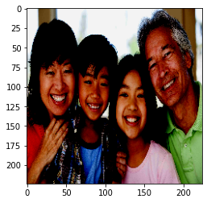

```python
plt.imshow(test_image)
```

```python
img_pred =img_pred.reshape(28,28)
```

```
WARNING:matplotlib.image:Clipping input data to the valid range for imshow with RGB data ([0..1] for floats or [0..255] for integers).
```

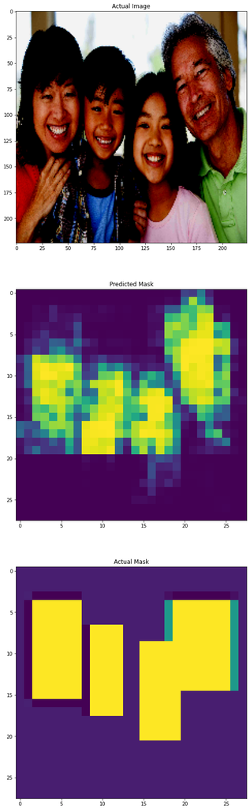

```python
pyplot.figure(figsize=(20,30))
pyplot.subplot(3,1,1)
pyplot.gca().set_title('Actual Image')
pyplot.imshow(test_image)
pyplot.subplot(3,1,2)
pyplot.gca().set_title('Predicted Mask')
pyplot.imshow(img_pred.reshape(28,28))
pyplot.subplot(3,1,3)
pyplot.gca().set_title('Actual Mask')
pyplot.imshow(masks_resize[1])
```

PART B

1.Read/import images from folder ‘training_images’.

```python
extract_path='/content/drive/MyDrive/data/CV2/'
```

```python
images_zip_path = '/content/drive/MyDrive/data/CV2/training_images-20211126T092819Z-001.zip'
from zipfile import ZipFile

with ZipFile(images_zip_path, 'r') as z:
  z.extractall(extract_path)
```

1. Write a loop which will iterate through all the images in the ‘training_images’ folder and detect the faces present on all the images.

```python
imgae_path =extract_path +"training_images/*.jpg"

files = glob(imgae_path)
```

```python
from google.colab.patches import cv2_imshow
face_cascade = cv2.CascadeClassifier(cv2.data.haarcascades + "haarcascade_frontalface_default.xml")
eye_cascade = cv2.CascadeClassifier(cv2.data.haarcascades +'haarcascade_eye.xml')
```

```python
df = pd.DataFrame(columns=['x','y','w','h','Total_Faces','Image_Name'])
```

```python
df.head(5)
```

|  | x | y | w | h | Total_Faces | Image_Name |
| --- | --- | --- | --- | --- | --- | --- |

```python
cv_img = []
trainLabel = []

for img in files:
  img = cv2.imread(img)
  gray = cv2.cvtColor(img, cv2.COLOR_BGR2GRAY)
  faces = face_cascade.detectMultiScale(gray, 1.3, 5)
  print(faces)
```

[output not shown]

[output not shown]

```python
img = cv2.cvtColor(img, cv2.IMREAD_GRAYSCALE)
faces = face_cascade.detectMultiScale(img,scaleFactor=1.1, minNeighbors=4)
print(faces)
#returns a list of (x,y,w,h) tuples
img_2 = cv2.cvtColor(img, cv2.COLOR_RGB2BGR) #converted to colored o/p image
for (x,y,w,h) in faces:
    cv2.rectangle(img_2,(x,y),(x+w,y+h),(0,0,250),2)

plt.figure(figsize=(12,12))
plt.imshow(img_2)
```

```python
img=images[275]
```

[figure not shown]

```python
plt.imshow(img)
```

```python
face_cascade = cv2.CascadeClassifier(cv2.data.haarcascades + "haarcascade_frontalface_default.xml")
eye_cascade = cv2.CascadeClassifier(cv2.data.haarcascades +'haarcascade_eye.xml')
```

```
[[ 73 149 398 398]]
```

[figure not shown]

```python
gray = cv2.cvtColor(img, cv2.COLOR_BGR2GRAY)
faces = face_cascade.detectMultiScale(gray, 1.3, 5)
print(faces)
for (x,y,w,h) in faces:
    img = cv2.rectangle(img,(x,y),(x+w,y+h),(255,0,0),2)
    roi_gray = gray[y:y+h, x:x+w]
    roi_color = img[y:y+h, x:x+w]
    eyes = eye_cascade.detectMultiScale(roi_gray)
    for (ex,ey,ew,eh) in eyes:
        cv2.rectangle(roi_color,(ex,ey),(ex+ew,ey+eh),(0,255,0),2)

cv2_imshow(img)
cv2.waitKey(0)
cv2.destroyAllWindows()
```

```
[[ 69 138 417 417]]
```

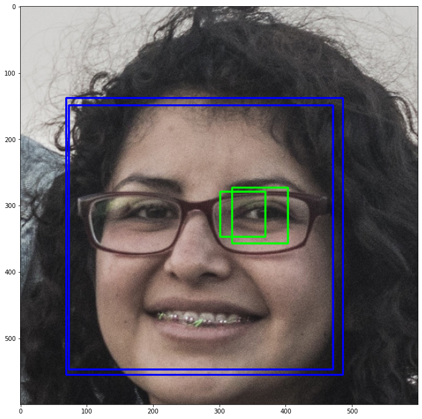

```python
img = cv2.cvtColor(img, cv2.IMREAD_GRAYSCALE)
faces = face_cascade.detectMultiScale(img,scaleFactor=1.1, minNeighbors=4)
print(faces)
#returns a list of (x,y,w,h) tuples
img_2 = cv2.cvtColor(img, cv2.COLOR_RGB2BGR) #converted to colored o/p image
for (x,y,w,h) in faces:
    cv2.rectangle(img_2,(x,y),(x+w,y+h),(0,0,250),2)

plt.figure(figsize=(12,12))
plt.imshow(img_2)
```

```python
df = pd.DataFrame(columns=['x','y','w','h','Total_Faces','Image_Name'])
```